# Lab09

```r
library(MASS)
```

## Exercise 1

Consider Auto dataset. Our aim is to predict mpg by horsepower by a regression tree. Use the full data set after removing the name variable as a training set. Use set.seed(20241031) just before fitting an regression tree model to mpg with respect to all other variables by using cp=0.000001 and minsplit=10. Look at the crossvalidation results. How many leafs this model has? How many leafs has the model with the best cp value? Which are 5 most important variables? Produce a graph of the part of the decision tree with first 15 splits.

```r
set.seed(20241031)

model1 <- rpart::rpart(mpg ~ .-name, data = Auto, cp = 0.000001, minsplit = 10)
```

```r
cp_min = as_tibble(model1$cptable) |> filter(xerror==min(xerror))|>slice(1)|>pull(CP)
cp_min
```

```
[1] 0.0003379728
```

```r
cp_15 = as_tibble(model1$cptable) |> filter(nsplit==14)|>slice(1)|>pull(CP)
cp_15
```

```
[1] 0.003155904
```

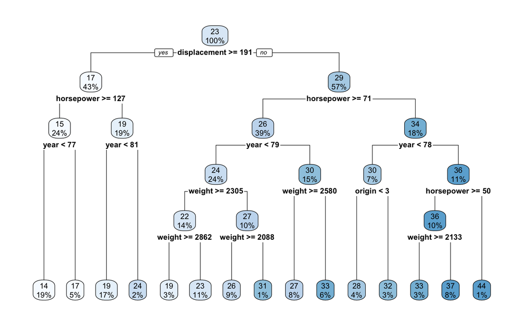

```r
rpart.plot::rpart.plot(rpart::prune(model1, cp=cp_15))
```

```r
model1$variable.importance
```

```
displacement       weight   horsepower    cylinders       origin acceleration         year
   17648.397    16316.437    13925.044    13482.965     8102.659     6498.450     2969.353
```

## Exercise 2

Use tidymodels framework and parameter tuning to determine the best cp value for a decision tree model.

```r
rec2=recipe(mpg~., data=Auto) |> step_rm(name)

tree_spec <- decision_tree(mode = "regression", cost_complexity = tune()) %>%
  set_engine("rpart", xval=0)

auto_folds <- vfold_cv(Auto, v = 10)

tree_wf <- workflow() %>%
  add_model(tree_spec) %>%
  add_recipe(rec2)

tune_grid = data.frame(cost_complexity=10^seq(-6,0,length.out=10))
tree_res <- tune_grid(
  tree_wf,
  resamples = auto_folds,
  grid = tune_grid,
  metrics = metric_set(rmse)
  )

show_best(tree_res, metric="rmse")
```

| cost_complexity | .metric | .estimator | mean | n | std_err | .config |
| --- | --- | --- | --- | --- | --- | --- |
| 1.000000e-04 | rmse | standard | 3.149432 | 10 | 0.1900043 | Preprocessor1_Model04 |
| 1.000000e-06 | rmse | standard | 3.150225 | 10 | 0.1900993 | Preprocessor1_Model01 |
| 4.641589e-06 | rmse | standard | 3.150225 | 10 | 0.1900993 | Preprocessor1_Model02 |
| 2.154435e-05 | rmse | standard | 3.150225 | 10 | 0.1900993 | Preprocessor1_Model03 |
| 4.641589e-04 | rmse | standard | 3.150358 | 10 | 0.1931175 | Preprocessor1_Model05 |

```r
wf2_fitted=tree_wf|>finalize_workflow(select_best(tree_res, metric="rmse"))|>fit(Auto)

wf2_fitted|>extract_fit_engine()
```

```
n= 392

node), split, n, deviance, yval
      * denotes terminal node

  1) root 392 23818.99000 23.44592
    2) displacement>=190.5 170  2210.18800 16.66000
      4) horsepower>=127 96   457.06620 14.51875
        8) year< 76.5 76   238.35200 13.82237
         16) weight>=4358.5 31    91.59677 12.85484
           32) year< 73.5 23    39.30435 12.17391
             64) acceleration>=13.25 7    10.85714 10.85714 *
             65) acceleration< 13.25 16    11.00000 12.75000 *
           33) year>=73.5 8    10.96875 14.81250 *
         17) weight< 4358.5 45    97.74444 14.48889
           34) weight>=3533.5 38    59.36842 14.23684
             68) weight< 4132 23    32.95652 13.95652
              136) year>=72.5 12    12.66667 13.33333 *
              137) year< 72.5 11    10.54545 14.63636 *
             69) weight>=4132 15    21.83333 14.66667 *
           35) weight< 3533.5 7    22.85714 15.85714 *
        9) year>=76.5 20    41.80550 17.16500
         18) weight>=3947.5 10     5.30900 15.99000 *
         19) weight< 3947.5 10     8.88400 18.34000 *
      5) horsepower< 127 74   741.95410 19.43784
       10) year< 78.5 60   258.36180 18.73833
         20) displacement>=241 26    78.78346 17.44231
           40) acceleration>=16.75 12    16.75000 16.25000 *
           41) acceleration< 16.75 14    30.35214 18.46429 *
         21) displacement< 241 34   102.51060 19.72941
           42) displacement>=212.5 24    52.89958 19.17917
             84) year< 75.5 14    19.42857 18.42857 *
             85) year>=75.5 10    14.54100 20.23000 *
           43) displacement< 212.5 10    24.90500 21.05000 *
       11) year>=78.5 14   328.41210 22.43571 *
    3) displacement< 190.5 222  7785.90200 28.64234
      6) horsepower>=70.5 151  3347.56000 26.28013
       12) year< 78.5 94  1222.09200 24.12021
         24) weight>=2305 55   413.66840 22.28545
           48) weight>=2861.5 12    50.04917 19.05833 *
```

[output cut: 15 more lines]

```
           53) origin>=2.5 7    76.82000 29.80000 *
         27) weight< 2580 24   294.23330 33.11667
           54) weight>=2237.5 15   162.30400 31.78000 *
           55) weight< 2237.5 9    60.46222 35.34444 *
      7) horsepower< 70.5 71  1803.77900 33.66620
       14) year< 77.5 28   280.25000 29.75000
         28) origin< 2.5 16   145.50000 28.00000 *
         29) origin>=2.5 12    20.41667 32.08333 *
       15) year>=77.5 43   814.47860 36.21628
         30) displacement>=97.5 14   101.03430 33.55714 *
         31) displacement< 97.5 29   566.66000 37.50000
           62) weight< 2067.5 21   290.59810 36.09048
            124) weight>=1969 12   131.62920 35.50833 *
            125) weight< 1969 9   149.48000 36.86667 *
           63) weight>=2067.5 8   124.82000 41.20000 *
```

```r
(wf2_fitted|>extract_fit_engine())$variable.importance
```

```
displacement       weight   horsepower    cylinders       origin acceleration         year
   17585.535    16110.618    13642.123    13451.173     8169.236     6233.204     2772.452
```

## Exercise 3

Consider the problem of approximating the function which is 1 in the unit circle and 0 otherwise by a regression tree. Fit the regression tree by rpart::rpart() to the data in lab9.csv with default parameters, visualize the shape of the obtained model with ggplot2 package and command geom_raster(). For producing the graph, use expand_grid(x1=seq(-1,1,length.out=40),x2=seq(-1,1,length.out=40)) to make a set of values for which to obtain predictions.

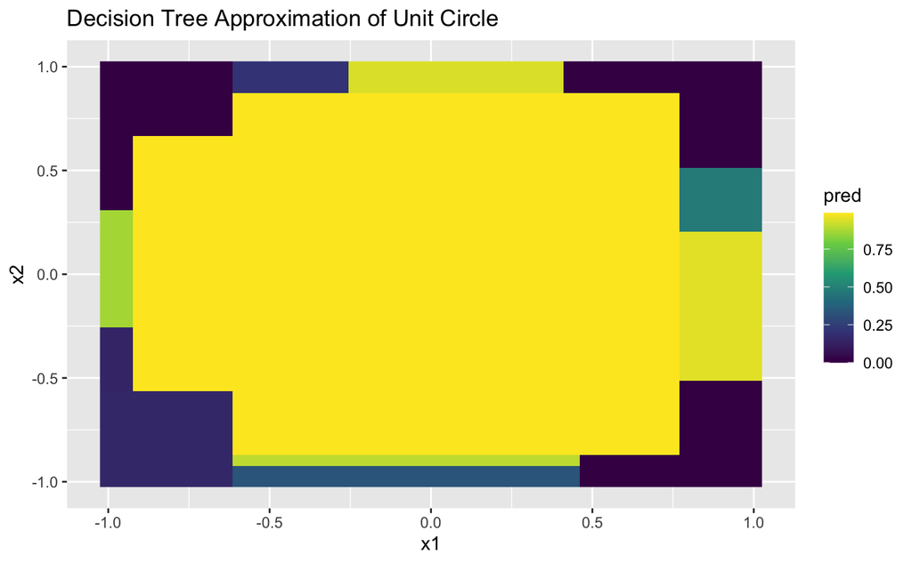

```r
# Exercise 3
# Load the data from lab9.csv
lab9_data <- read.csv("lab9.csv")

# Fit the regression tree with default parameters
circle_tree <- rpart(y ~ x1 + x2, data = lab9_data, method="anova")

# Prepare grid for visualization
grid <- expand_grid(x1 = seq(-1, 1, length.out = 40), x2 = seq(-1, 1, length.out = 40))
grid$pred <- predict(circle_tree, newdata = grid)

# Plot using ggplot2
ggplot(grid, aes(x = x1, y = x2, fill = pred)) +
  geom_raster() +
  scale_fill_viridis_c() +
  labs(title = "Decision Tree Approximation of Unit Circle")
```

## Exercise 4.

Consider Boston dataset from the MASS library (accessible through MASS::Boston). The aim is to predict medv (median value of owner occupied homes in 1000USD).

```r
# Exercise 4
# Load Boston dataset
data(Boston)

# Split the data into training and test sets
boston_split <- initial_split(Boston, prop = 0.7)
boston_train <- training(boston_split)
boston_test <- testing(boston_split)

# 4.1 Determine best decision tree model
boston_tree_spec <- decision_tree(mode = "regression", cost_complexity = tune()) %>%
  set_engine("rpart")

# Set up cross-validation
boston_folds <- vfold_cv(boston_train, v = 5)

# Create a workflow
boston_tree_wf <- workflow() %>%
  add_model(boston_tree_spec) %>%
  add_formula(medv ~ .)

# Perform parameter tuning for cp
boston_tree_grid <- grid_regular(cost_complexity(), levels = 10)
boston_tree_res <- tune_grid(boston_tree_wf, resamples = boston_folds, grid = boston_tree_grid, metrics = metric_set(rmse))

# Get the best model based on RMSE
best_boston_tree <- select_best(boston_tree_res, metric="rmse")
cat("Best cp for Boston tree:", best_boston_tree$cost_complexity, "\n")
```

```
Best cp for Boston tree: 1e-10
```

```r
# Finalize and fit the model with the best cp
final_boston_tree <- finalize_workflow(boston_tree_wf, best_boston_tree)
final_tree_model <- fit(final_boston_tree, data = boston_train)

final_tree_model$variables.importance
```

[output not shown]

```r
# Predict and compute RMSE on test data
boston_tree_predictions <- predict(final_tree_model, new_data = boston_test) %>%
  bind_cols(boston_test) %>%
  metrics(truth = medv, estimate = .pred) %>%
  filter(.metric == "rmse")
cat("RMSE for best decision tree on test data:", boston_tree_predictions$.estimate, "\n")
```

```
RMSE for best decision tree on test data: 4.871277
```

```r
# 4.2 Tune kNN model using all variables
knn_spec <- nearest_neighbor(mode = "regression", neighbors = tune()) %>%
  set_engine("kknn")

# Create workflow and tune kNN model
knn_wf <- workflow() %>%
  add_model(knn_spec) %>%
  add_formula(medv ~ .)
knn_grid <- grid_regular(neighbors(), levels = 10)
knn_res <- tune_grid(knn_wf, resamples = boston_folds, grid = knn_grid, metrics = metric_set(rmse))

# Get the best k for kNN
best_knn <- select_best(knn_res, metric = "rmse")
cat("Best k for kNN model:", best_knn$neighbors, "\n")
```

```
Best k for kNN model: 3
```

```r
# Finalize and fit best kNN model
final_knn <- finalize_workflow(knn_wf, best_knn)
final_knn_model <- fit(final_knn, data = boston_train)

# Predict and compute RMSE on test data for kNN model
knn_predictions <- predict(final_knn_model, new_data = boston_test) %>%
  bind_cols(boston_test) %>%
  metrics(truth = medv, estimate = .pred) %>%
  filter(.metric == "rmse")
cat("RMSE for best kNN on test data:", knn_predictions$.estimate, "\n")
```

```
RMSE for best kNN on test data: 3.854893
```

```r
# 4.3 kNN using top 5 important variables from decision tree

# Fit model directly with rpart
direct_tree_model <- rpart(medv ~ ., data = boston_train, method = "anova", cp = best_boston_tree$cost_complexity)

# Get variable importance
important_vars <- direct_tree_model$variable.importance

top5_vars <- names(sort(important_vars, decreasing = TRUE)[1:5])

# Check the top 5 variables
print(top5_vars)
```

```
[1] "rm"    "lstat" "indus" "nox"   "dis"
```

```r
# Create the kNN workflow with only the top 5 important variables
knn_wf_top5 <- workflow() %>%
  add_model(knn_spec) %>%
  add_formula(reformulate(top5_vars, response = "medv"))

# Tune kNN with top 5 variables
knn_res_top5 <- tune_grid(knn_wf_top5, resamples = boston_folds, grid = knn_grid, metrics = metric_set(rmse))

# Get the best k for kNN with top 5 variables
best_knn_top5 <- select_best(knn_res_top5, metric = "rmse")
cat("Best k for kNN with top 5 variables:", best_knn_top5$neighbors, "\n")
```

```
Best k for kNN with top 5 variables: 6
```

```r
# Finalize and fit best kNN model with top 5 variables
final_knn_top5 <- finalize_workflow(knn_wf_top5, best_knn_top5)
final_knn_model_top5 <- fit(final_knn_top5, data = boston_train)

# Predict and compute RMSE on test data for kNN with top 5 variables
knn_predictions_top5 <- predict(final_knn_model_top5, new_data = boston_test) %>%
  bind_cols(boston_test) %>%
  metrics(truth = medv, estimate = .pred) %>%
  filter(.metric == "rmse")
cat("RMSE for kNN with top 5 variables on test data:", knn_predictions_top5$.estimate, "\n")
```

```
RMSE for kNN with top 5 variables on test data: 3.904793
```

```r
final_boston_model
```

[output not shown]